# Risk Factor Analysis

## Outcome Variable

**Outcome Variable:** ever_wasted

## Predictor Variables

**Intervention Variable:** hfoodsec

**Adjustment Set:**

- arm
- sex
- W_mage
- meducyrs
- feducyrs
- hhwealth_quart
- vagbrth
- W_nrooms
- W_nchldlt5
- brthmon
- W_parity
- impfloor
- impsan
- safeh20
- delta_W_mage
- delta_meducyrs
- delta_feducyrs
- delta_hhwealth_quart
- delta_vagbrth
- delta_W_nrooms
- delta_W_nchldlt5
- delta_brthmon
- delta_W_parity
- delta_impfloor
- delta_impsan
- delta_safeh20

## Stratifying Variables

The analysis was stratified on these variable(s):

- agecat
- studyid
- country

## Data Summary

| agecat | studyid | country | hfoodsec | ever_wasted | n_cell | n |
| --- | --- | --- | --- | --- | --- | --- |
| 0-24 months | GMS-Nepal | NEPAL | Food Secure | 0 | 188 | 663 |
| 0-24 months | GMS-Nepal | NEPAL | Food Secure | 1 | 283 | 663 |
| 0-24 months | GMS-Nepal | NEPAL | Mildly Food Insecure | 0 | 55 | 663 |
| 0-24 months | GMS-Nepal | NEPAL | Mildly Food Insecure | 1 | 50 | 663 |
| 0-24 months | GMS-Nepal | NEPAL | Food Insecure | 0 | 28 | 663 |
| 0-24 months | GMS-Nepal | NEPAL | Food Insecure | 1 | 59 | 663 |
| 0-24 months | JiVitA-3 | BANGLADESH | Food Secure | 0 | 6332 | 17375 |
| 0-24 months | JiVitA-3 | BANGLADESH | Food Secure | 1 | 2364 | 17375 |
| 0-24 months | JiVitA-3 | BANGLADESH | Mildly Food Insecure | 0 | 4087 | 17375 |
| 0-24 months | JiVitA-3 | BANGLADESH | Mildly Food Insecure | 1 | 1697 | 17375 |
| 0-24 months | JiVitA-3 | BANGLADESH | Food Insecure | 0 | 1924 | 17375 |
| 0-24 months | JiVitA-3 | BANGLADESH | Food Insecure | 1 | 971 | 17375 |
| 0-24 months | JiVitA-4 | BANGLADESH | Food Secure | 0 | 1896 | 5399 |
| 0-24 months | JiVitA-4 | BANGLADESH | Food Secure | 1 | 853 | 5399 |
| 0-24 months | JiVitA-4 | BANGLADESH | Mildly Food Insecure | 0 | 1333 | 5399 |
| 0-24 months | JiVitA-4 | BANGLADESH | Mildly Food Insecure | 1 | 615 | 5399 |
| 0-24 months | JiVitA-4 | BANGLADESH | Food Insecure | 0 | 494 | 5399 |
| 0-24 months | JiVitA-4 | BANGLADESH | Food Insecure | 1 | 208 | 5399 |
| 0-24 months | MAL-ED | BANGLADESH | Food Secure | 0 | 105 | 194 |
| 0-24 months | MAL-ED | BANGLADESH | Food Secure | 1 | 56 | 194 |
| 0-24 months | MAL-ED | BANGLADESH | Mildly Food Insecure | 0 | 3 | 194 |
| 0-24 months | MAL-ED | BANGLADESH | Mildly Food Insecure | 1 | 1 | 194 |
| 0-24 months | MAL-ED | BANGLADESH | Food Insecure | 0 | 19 | 194 |
| 0-24 months | MAL-ED | BANGLADESH | Food Insecure | 1 | 10 | 194 |
| 0-24 months | MAL-ED | BRAZIL | Food Secure | 0 | 3 | 129 |
| 0-24 months | MAL-ED | BRAZIL | Food Secure | 1 | 0 | 129 |
| 0-24 months | MAL-ED | BRAZIL | Mildly Food Insecure | 0 | 11 | 129 |
| 0-24 months | MAL-ED | BRAZIL | Mildly Food Insecure | 1 | 0 | 129 |
| 0-24 months | MAL-ED | BRAZIL | Food Insecure | 0 | 103 | 129 |
| 0-24 months | MAL-ED | BRAZIL | Food Insecure | 1 | 12 | 129 |

[output cut: 168 more lines]

The following strata were considered:

- agecat: 0-24 months, studyid: GMS-Nepal, country: NEPAL
- agecat: 0-24 months, studyid: JiVitA-3, country: BANGLADESH
- agecat: 0-24 months, studyid: JiVitA-4, country: BANGLADESH
- agecat: 0-24 months, studyid: MAL-ED, country: BANGLADESH
- agecat: 0-24 months, studyid: MAL-ED, country: BRAZIL
- agecat: 0-24 months, studyid: MAL-ED, country: INDIA
- agecat: 0-24 months, studyid: MAL-ED, country: NEPAL
- agecat: 0-24 months, studyid: MAL-ED, country: PERU
- agecat: 0-24 months, studyid: MAL-ED, country: SOUTH AFRICA
- agecat: 0-24 months, studyid: NIH-Birth, country: BANGLADESH
- agecat: 0-24 months, studyid: NIH-Crypto, country: BANGLADESH
- agecat: 0-6 months, studyid: GMS-Nepal, country: NEPAL
- agecat: 0-6 months, studyid: JiVitA-3, country: BANGLADESH
- agecat: 0-6 months, studyid: JiVitA-4, country: BANGLADESH
- agecat: 0-6 months, studyid: MAL-ED, country: BANGLADESH
- agecat: 0-6 months, studyid: MAL-ED, country: BRAZIL
- agecat: 0-6 months, studyid: MAL-ED, country: INDIA
- agecat: 0-6 months, studyid: MAL-ED, country: NEPAL
- agecat: 0-6 months, studyid: MAL-ED, country: PERU
- agecat: 0-6 months, studyid: MAL-ED, country: SOUTH AFRICA
- agecat: 0-6 months, studyid: NIH-Birth, country: BANGLADESH
- agecat: 0-6 months, studyid: NIH-Crypto, country: BANGLADESH
- agecat: 6-24 months, studyid: GMS-Nepal, country: NEPAL
- agecat: 6-24 months, studyid: JiVitA-3, country: BANGLADESH
- agecat: 6-24 months, studyid: JiVitA-4, country: BANGLADESH
- agecat: 6-24 months, studyid: MAL-ED, country: BANGLADESH
- agecat: 6-24 months, studyid: MAL-ED, country: BRAZIL
- agecat: 6-24 months, studyid: MAL-ED, country: INDIA
- agecat: 6-24 months, studyid: MAL-ED, country: NEPAL
- agecat: 6-24 months, studyid: MAL-ED, country: PERU
- agecat: 6-24 months, studyid: MAL-ED, country: SOUTH AFRICA
- agecat: 6-24 months, studyid: NIH-Birth, country: BANGLADESH
- agecat: 6-24 months, studyid: NIH-Crypto, country: BANGLADESH

### Dropped Strata

Some strata were dropped due to rare outcomes:

- agecat: 0-24 months, studyid: MAL-ED, country: BANGLADESH
- agecat: 0-24 months, studyid: MAL-ED, country: BRAZIL
- agecat: 0-24 months, studyid: MAL-ED, country: INDIA
- agecat: 0-24 months, studyid: MAL-ED, country: PERU
- agecat: 0-24 months, studyid: MAL-ED, country: SOUTH AFRICA
- agecat: 0-6 months, studyid: MAL-ED, country: BANGLADESH
- agecat: 0-6 months, studyid: MAL-ED, country: BRAZIL
- agecat: 0-6 months, studyid: MAL-ED, country: INDIA
- agecat: 0-6 months, studyid: MAL-ED, country: NEPAL
- agecat: 0-6 months, studyid: MAL-ED, country: PERU
- agecat: 0-6 months, studyid: MAL-ED, country: SOUTH AFRICA
- agecat: 6-24 months, studyid: MAL-ED, country: BANGLADESH
- agecat: 6-24 months, studyid: MAL-ED, country: BRAZIL
- agecat: 6-24 months, studyid: MAL-ED, country: INDIA
- agecat: 6-24 months, studyid: MAL-ED, country: NEPAL
- agecat: 6-24 months, studyid: MAL-ED, country: PERU
- agecat: 6-24 months, studyid: MAL-ED, country: SOUTH AFRICA

## Methods Detail

We're interested in the causal parameters $E[Y_a]$ for all values of $a \in \mathcal{A}$. These parameters represent the mean outcome if, possibly contrary to fact, we intervened to set all units to have $A=a$. Under the randomization and positivity assumptions, these are identified by the statistical parameters $\psi_a=E_W[E_{Y|A,W}(Y|A=a,W)]$. In addition, we're interested in the mean of $Y$, $E[Y]$ under no intervention (the observed mean). We will estimate these parameters by using SuperLearner to fit the relevant likelihood factors -- $E_{Y|A,W}(Y|A=a,W)$ and $p(A=a|W)$, and then updating our likelihood fit using a joint TMLE.

For unadjusted analyses ($W=\{\}$), initial likelihoods were estimated using Lrnr_glm to estimate the simple $E(Y|A)$ and Lrnr_mean to estimate $p(A)$. For adjusted analyses, a small library containing Lrnr_glmnet, Lrnr_xgboost, and Lrnr_mean was used.

Having estimated these parameters, we will then use the delta method to estimate relative risks and attributable risks relative to a prespecified baseline level of $A$.

# Results Detail

## Results Plots

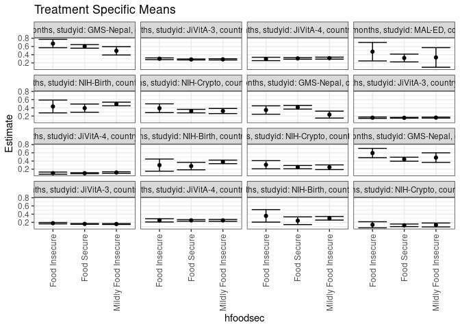

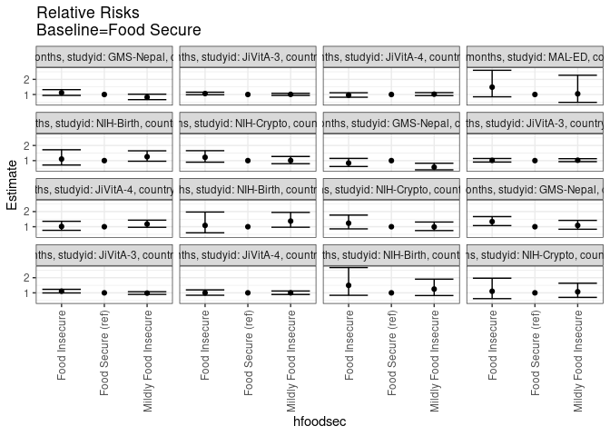

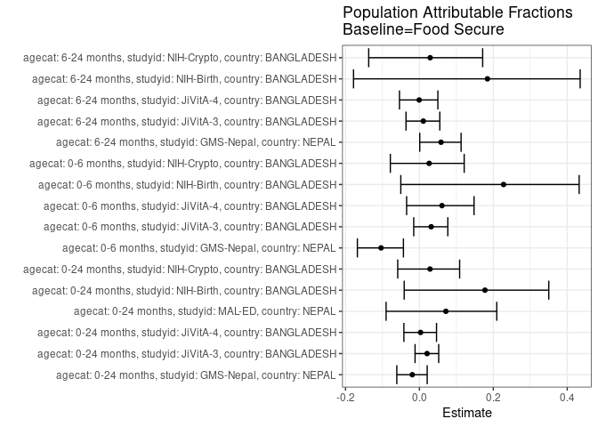

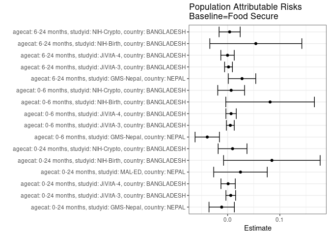

## Results Table

### Parameter: TSM

| agecat | studyid | country | intervention_level | baseline_level | estimate | ci_lower | ci_upper |
| --- | --- | --- | --- | --- | --- | --- | --- |
| 0-24 months | GMS-Nepal | NEPAL | Food Secure | NA | 0.6026365 | 0.5582410 | 0.6470319 |
| 0-24 months | GMS-Nepal | NEPAL | Mildly Food Insecure | NA | 0.4944140 | 0.3926256 | 0.5962024 |
| 0-24 months | GMS-Nepal | NEPAL | Food Insecure | NA | 0.6721705 | 0.5703185 | 0.7740226 |
| 0-24 months | JiVitA-3 | BANGLADESH | Food Secure | NA | 0.2836197 | 0.2714215 | 0.2958178 |
| 0-24 months | JiVitA-3 | BANGLADESH | Mildly Food Insecure | NA | 0.2860009 | 0.2708706 | 0.3011311 |
| 0-24 months | JiVitA-3 | BANGLADESH | Food Insecure | NA | 0.3010710 | 0.2797515 | 0.3223906 |
| 0-24 months | JiVitA-4 | BANGLADESH | Food Secure | NA | 0.3094644 | 0.2896450 | 0.3292838 |
| 0-24 months | JiVitA-4 | BANGLADESH | Mildly Food Insecure | NA | 0.3159411 | 0.2919957 | 0.3398864 |
| 0-24 months | JiVitA-4 | BANGLADESH | Food Insecure | NA | 0.2958958 | 0.2547104 | 0.3370811 |
| 0-24 months | MAL-ED | NEPAL | Food Secure | NA | 0.3191489 | 0.2245448 | 0.4137531 |
| 0-24 months | MAL-ED | NEPAL | Mildly Food Insecure | NA | 0.3333333 | 0.0938367 | 0.5728299 |
| 0-24 months | MAL-ED | NEPAL | Food Insecure | NA | 0.4736842 | 0.2482904 | 0.6990781 |
| 0-24 months | NIH-Birth | BANGLADESH | Food Secure | NA | 0.3928568 | 0.2929752 | 0.4927384 |
| 0-24 months | NIH-Birth | BANGLADESH | Mildly Food Insecure | NA | 0.4938093 | 0.4493855 | 0.5382330 |
| 0-24 months | NIH-Birth | BANGLADESH | Food Insecure | NA | 0.4335938 | 0.2771319 | 0.5900556 |
| 0-24 months | NIH-Crypto | BANGLADESH | Food Secure | NA | 0.3203679 | 0.2773344 | 0.3634015 |
| 0-24 months | NIH-Crypto | BANGLADESH | Mildly Food Insecure | NA | 0.3224695 | 0.2602791 | 0.3846599 |
| 0-24 months | NIH-Crypto | BANGLADESH | Food Insecure | NA | 0.3905107 | 0.2830600 | 0.4979614 |
| 0-6 months | GMS-Nepal | NEPAL | Food Secure | NA | 0.4145555 | 0.3697893 | 0.4593218 |
| 0-6 months | GMS-Nepal | NEPAL | Mildly Food Insecure | NA | 0.2353324 | 0.1508134 | 0.3198513 |
| 0-6 months | GMS-Nepal | NEPAL | Food Insecure | NA | 0.3468063 | 0.2445441 | 0.4490684 |
| 0-6 months | JiVitA-3 | BANGLADESH | Food Secure | NA | 0.1578292 | 0.1479371 | 0.1677212 |
| 0-6 months | JiVitA-3 | BANGLADESH | Mildly Food Insecure | NA | 0.1619228 | 0.1504893 | 0.1733562 |
| 0-6 months | JiVitA-3 | BANGLADESH | Food Insecure | NA | 0.1603167 | 0.1438071 | 0.1768264 |
| 0-6 months | JiVitA-4 | BANGLADESH | Food Secure | NA | 0.1019006 | 0.0887130 | 0.1150881 |
| 0-6 months | JiVitA-4 | BANGLADESH | Mildly Food Insecure | NA | 0.1196539 | 0.1016598 | 0.1376479 |
| 0-6 months | JiVitA-4 | BANGLADESH | Food Insecure | NA | 0.1037131 | 0.0772784 | 0.1301478 |
| 0-6 months | NIH-Birth | BANGLADESH | Food Secure | NA | 0.2756151 | 0.1847032 | 0.3665271 |
| 0-6 months | NIH-Birth | BANGLADESH | Mildly Food Insecure | NA | 0.3783009 | 0.3351678 | 0.4214339 |
| 0-6 months | NIH-Birth | BANGLADESH | Food Insecure | NA | 0.2995154 | 0.1511105 | 0.4479204 |
| 0-6 months | NIH-Crypto | BANGLADESH | Food Secure | NA | 0.2504808 | 0.2104658 | 0.2904958 |
| 0-6 months | NIH-Crypto | BANGLADESH | Mildly Food Insecure | NA | 0.2477318 | 0.1903197 | 0.3051439 |
| 0-6 months | NIH-Crypto | BANGLADESH | Food Insecure | NA | 0.3087898 | 0.2089100 | 0.4086695 |
| 6-24 months | GMS-Nepal | NEPAL | Food Secure | NA | 0.4436466 | 0.3953072 | 0.4919859 |
| 6-24 months | GMS-Nepal | NEPAL | Mildly Food Insecure | NA | 0.4822646 | 0.3650547 | 0.5994744 |
| 6-24 months | GMS-Nepal | NEPAL | Food Insecure | NA | 0.5939151 | 0.4803842 | 0.7074460 |
| 6-24 months | JiVitA-3 | BANGLADESH | Food Secure | NA | 0.1622526 | 0.1527319 | 0.1717734 |
| 6-24 months | JiVitA-3 | BANGLADESH | Mildly Food Insecure | NA | 0.1592635 | 0.1480667 | 0.1704603 |
| 6-24 months | JiVitA-3 | BANGLADESH | Food Insecure | NA | 0.1794442 | 0.1624001 | 0.1964883 |
| 6-24 months | JiVitA-4 | BANGLADESH | Food Secure | NA | 0.2474801 | 0.2285232 | 0.2664370 |
| 6-24 months | JiVitA-4 | BANGLADESH | Mildly Food Insecure | NA | 0.2474838 | 0.2255632 | 0.2694043 |
| 6-24 months | JiVitA-4 | BANGLADESH | Food Insecure | NA | 0.2481756 | 0.2088230 | 0.2875283 |
| 6-24 months | NIH-Birth | BANGLADESH | Food Secure | NA | 0.2393636 | 0.1451597 | 0.3335675 |
| 6-24 months | NIH-Birth | BANGLADESH | Mildly Food Insecure | NA | 0.2993304 | 0.2555154 | 0.3431454 |
| 6-24 months | NIH-Birth | BANGLADESH | Food Insecure | NA | 0.3577126 | 0.2055142 | 0.5099109 |
| 6-24 months | NIH-Crypto | BANGLADESH | Food Secure | NA | 0.1276771 | 0.0963228 | 0.1590314 |
| 6-24 months | NIH-Crypto | BANGLADESH | Mildly Food Insecure | NA | 0.1365938 | 0.0893086 | 0.1838789 |
| 6-24 months | NIH-Crypto | BANGLADESH | Food Insecure | NA | 0.1408619 | 0.0670496 | 0.2146742 |

### Parameter: E(Y)

| agecat | studyid | country | intervention_level | baseline_level | estimate | ci_lower | ci_upper |
| --- | --- | --- | --- | --- | --- | --- | --- |
| 0-24 months | GMS-Nepal | NEPAL | NA | NA | 0.5912519 | 0.5538035 | 0.6287003 |
| 0-24 months | JiVitA-3 | BANGLADESH | NA | NA | 0.2896115 | 0.2819717 | 0.2972513 |
| 0-24 months | JiVitA-4 | BANGLADESH | NA | NA | 0.3104279 | 0.2959885 | 0.3248672 |
| 0-24 months | MAL-ED | NEPAL | NA | NA | 0.3437500 | 0.2611458 | 0.4263542 |
| 0-24 months | NIH-Birth | BANGLADESH | NA | NA | 0.4775641 | 0.4383415 | 0.5167867 |
| 0-24 months | NIH-Crypto | BANGLADESH | NA | NA | 0.3298153 | 0.2963239 | 0.3633067 |
| 0-6 months | GMS-Nepal | NEPAL | NA | NA | 0.3755656 | 0.3386759 | 0.4124553 |
| 0-6 months | JiVitA-3 | BANGLADESH | NA | NA | 0.1630114 | 0.1568185 | 0.1692043 |
| 0-6 months | JiVitA-4 | BANGLADESH | NA | NA | 0.1085195 | 0.0986291 | 0.1184098 |
| 0-6 months | NIH-Birth | BANGLADESH | NA | NA | 0.3569132 | 0.3192325 | 0.3945938 |
| 0-6 months | NIH-Crypto | BANGLADESH | NA | NA | 0.2572559 | 0.2261171 | 0.2883948 |
| 6-24 months | GMS-Nepal | NEPAL | NA | NA | 0.4712042 | 0.4302971 | 0.5121113 |
| 6-24 months | JiVitA-3 | BANGLADESH | NA | NA | 0.1639687 | 0.1578505 | 0.1700868 |
| 6-24 months | JiVitA-4 | BANGLADESH | NA | NA | 0.2473078 | 0.2336663 | 0.2609494 |
| 6-24 months | NIH-Birth | BANGLADESH | NA | NA | 0.2933579 | 0.2549918 | 0.3317241 |
| 6-24 months | NIH-Crypto | BANGLADESH | NA | NA | 0.1315068 | 0.1069744 | 0.1560393 |

### Parameter: RR

| agecat | studyid | country | intervention_level | baseline_level | estimate | ci_lower | ci_upper |
| --- | --- | --- | --- | --- | --- | --- | --- |
| 0-24 months | GMS-Nepal | NEPAL | Food Secure | Food Secure | 1.0000000 | 1.0000000 | 1.0000000 |
| 0-24 months | GMS-Nepal | NEPAL | Mildly Food Insecure | Food Secure | 0.8204183 | 0.6592634 | 1.0209671 |
| 0-24 months | GMS-Nepal | NEPAL | Food Insecure | Food Secure | 1.1153831 | 0.9423758 | 1.3201522 |
| 0-24 months | JiVitA-3 | BANGLADESH | Food Secure | Food Secure | 1.0000000 | 1.0000000 | 1.0000000 |
| 0-24 months | JiVitA-3 | BANGLADESH | Mildly Food Insecure | Food Secure | 1.0083958 | 0.9417453 | 1.0797634 |
| 0-24 months | JiVitA-3 | BANGLADESH | Food Insecure | Food Secure | 1.0615309 | 0.9803359 | 1.1494508 |
| 0-24 months | JiVitA-4 | BANGLADESH | Food Secure | Food Secure | 1.0000000 | 1.0000000 | 1.0000000 |
| 0-24 months | JiVitA-4 | BANGLADESH | Mildly Food Insecure | Food Secure | 1.0209286 | 0.9268489 | 1.1245580 |
| 0-24 months | JiVitA-4 | BANGLADESH | Food Insecure | Food Secure | 0.9561544 | 0.8194882 | 1.1156125 |
| 0-24 months | MAL-ED | NEPAL | Food Secure | Food Secure | 1.0000000 | 1.0000000 | 1.0000000 |
| 0-24 months | MAL-ED | NEPAL | Mildly Food Insecure | Food Secure | 1.0444444 | 0.4801047 | 2.2721381 |
| 0-24 months | MAL-ED | NEPAL | Food Insecure | Food Secure | 1.4842105 | 0.8472771 | 2.5999533 |
| 0-24 months | NIH-Birth | BANGLADESH | Food Secure | Food Secure | 1.0000000 | 1.0000000 | 1.0000000 |
| 0-24 months | NIH-Birth | BANGLADESH | Mildly Food Insecure | Food Secure | 1.2569701 | 0.9598425 | 1.6460760 |
| 0-24 months | NIH-Birth | BANGLADESH | Food Insecure | Food Secure | 1.1036942 | 0.7097010 | 1.7164140 |
| 0-24 months | NIH-Crypto | BANGLADESH | Food Secure | Food Secure | 1.0000000 | 1.0000000 | 1.0000000 |
| 0-24 months | NIH-Crypto | BANGLADESH | Mildly Food Insecure | Food Secure | 1.0065598 | 0.7959406 | 1.2729123 |
| 0-24 months | NIH-Crypto | BANGLADESH | Food Insecure | Food Secure | 1.2189445 | 0.8973549 | 1.6557836 |
| 0-6 months | GMS-Nepal | NEPAL | Food Secure | Food Secure | 1.0000000 | 1.0000000 | 1.0000000 |
| 0-6 months | GMS-Nepal | NEPAL | Mildly Food Insecure | Food Secure | 0.5676740 | 0.3900236 | 0.8262417 |
| 0-6 months | GMS-Nepal | NEPAL | Food Insecure | Food Secure | 0.8365737 | 0.6109959 | 1.1454342 |
| 0-6 months | JiVitA-3 | BANGLADESH | Food Secure | Food Secure | 1.0000000 | 1.0000000 | 1.0000000 |
| 0-6 months | JiVitA-3 | BANGLADESH | Mildly Food Insecure | Food Secure | 1.0259369 | 0.9334104 | 1.1276353 |
| 0-6 months | JiVitA-3 | BANGLADESH | Food Insecure | Food Secure | 1.0157612 | 0.9048426 | 1.1402766 |
| 0-6 months | JiVitA-4 | BANGLADESH | Food Secure | Food Secure | 1.0000000 | 1.0000000 | 1.0000000 |
| 0-6 months | JiVitA-4 | BANGLADESH | Mildly Food Insecure | Food Secure | 1.1742218 | 0.9616682 | 1.4337552 |
| 0-6 months | JiVitA-4 | BANGLADESH | Food Insecure | Food Secure | 1.0177870 | 0.7625577 | 1.3584421 |
| 0-6 months | NIH-Birth | BANGLADESH | Food Secure | Food Secure | 1.0000000 | 1.0000000 | 1.0000000 |
| 0-6 months | NIH-Birth | BANGLADESH | Mildly Food Insecure | Food Secure | 1.3725692 | 0.9676627 | 1.9469038 |
| 0-6 months | NIH-Birth | BANGLADESH | Food Insecure | Food Secure | 1.0867162 | 0.5995531 | 1.9697205 |
| 0-6 months | NIH-Crypto | BANGLADESH | Food Secure | Food Secure | 1.0000000 | 1.0000000 | 1.0000000 |
| 0-6 months | NIH-Crypto | BANGLADESH | Mildly Food Insecure | Food Secure | 0.9890250 | 0.7464197 | 1.3104831 |
| 0-6 months | NIH-Crypto | BANGLADESH | Food Insecure | Food Secure | 1.2327880 | 0.8593665 | 1.7684727 |
| 6-24 months | GMS-Nepal | NEPAL | Food Secure | Food Secure | 1.0000000 | 1.0000000 | 1.0000000 |
| 6-24 months | GMS-Nepal | NEPAL | Mildly Food Insecure | Food Secure | 1.0870468 | 0.8332696 | 1.4181134 |
| 6-24 months | GMS-Nepal | NEPAL | Food Insecure | Food Secure | 1.3387123 | 1.0743902 | 1.6680631 |
| 6-24 months | JiVitA-3 | BANGLADESH | Food Secure | Food Secure | 1.0000000 | 1.0000000 | 1.0000000 |
| 6-24 months | JiVitA-3 | BANGLADESH | Mildly Food Insecure | Food Secure | 0.9815776 | 0.8971933 | 1.0738986 |
| 6-24 months | JiVitA-3 | BANGLADESH | Food Insecure | Food Secure | 1.1059555 | 0.9929931 | 1.2317684 |
| 6-24 months | JiVitA-4 | BANGLADESH | Food Secure | Food Secure | 1.0000000 | 1.0000000 | 1.0000000 |
| 6-24 months | JiVitA-4 | BANGLADESH | Mildly Food Insecure | Food Secure | 1.0000149 | 0.8922852 | 1.1207513 |
| 6-24 months | JiVitA-4 | BANGLADESH | Food Insecure | Food Secure | 1.0028104 | 0.8407028 | 1.1961762 |
| 6-24 months | NIH-Birth | BANGLADESH | Food Secure | Food Secure | 1.0000000 | 1.0000000 | 1.0000000 |
| 6-24 months | NIH-Birth | BANGLADESH | Mildly Food Insecure | Food Secure | 1.2505261 | 0.8214552 | 1.9037137 |
| 6-24 months | NIH-Birth | BANGLADESH | Food Insecure | Food Secure | 1.4944318 | 0.8367997 | 2.6688902 |
| 6-24 months | NIH-Crypto | BANGLADESH | Food Secure | Food Secure | 1.0000000 | 1.0000000 | 1.0000000 |
| 6-24 months | NIH-Crypto | BANGLADESH | Mildly Food Insecure | Food Secure | 1.0698376 | 0.6997580 | 1.6356402 |
| 6-24 months | NIH-Crypto | BANGLADESH | Food Insecure | Food Secure | 1.1032665 | 0.6185213 | 1.9679142 |

### Parameter: PAR

| agecat | studyid | country | intervention_level | baseline_level | estimate | ci_lower | ci_upper |
| --- | --- | --- | --- | --- | --- | --- | --- |
| 0-24 months | GMS-Nepal | NEPAL | Food Secure | NA | -0.0113846 | -0.0356673 | 0.0128982 |
| 0-24 months | JiVitA-3 | BANGLADESH | Food Secure | NA | 0.0059919 | -0.0032653 | 0.0152490 |
| 0-24 months | JiVitA-4 | BANGLADESH | Food Secure | NA | 0.0009634 | -0.0127457 | 0.0146726 |
| 0-24 months | MAL-ED | NEPAL | Food Secure | NA | 0.0246011 | -0.0266646 | 0.0758668 |
| 0-24 months | NIH-Birth | BANGLADESH | Food Secure | NA | 0.0847073 | -0.0077167 | 0.1771313 |
| 0-24 months | NIH-Crypto | BANGLADESH | Food Secure | NA | 0.0094474 | -0.0181491 | 0.0370438 |
| 0-6 months | GMS-Nepal | NEPAL | Food Secure | NA | -0.0389899 | -0.0622959 | -0.0156839 |
| 0-6 months | JiVitA-3 | BANGLADESH | Food Secure | NA | 0.0051822 | -0.0023216 | 0.0126861 |
| 0-6 months | JiVitA-4 | BANGLADESH | Food Secure | NA | 0.0066189 | -0.0033170 | 0.0165549 |
| 0-6 months | NIH-Birth | BANGLADESH | Food Secure | NA | 0.0812980 | -0.0035375 | 0.1661335 |
| 0-6 months | NIH-Crypto | BANGLADESH | Food Secure | NA | 0.0067751 | -0.0188886 | 0.0324387 |
| 6-24 months | GMS-Nepal | NEPAL | Food Secure | NA | 0.0275576 | 0.0012940 | 0.0538213 |
| 6-24 months | JiVitA-3 | BANGLADESH | Food Secure | NA | 0.0017160 | -0.0057731 | 0.0092051 |
| 6-24 months | JiVitA-4 | BANGLADESH | Food Secure | NA | -0.0001722 | -0.0130198 | 0.0126753 |
| 6-24 months | NIH-Birth | BANGLADESH | Food Secure | NA | 0.0539944 | -0.0340627 | 0.1420514 |
| 6-24 months | NIH-Crypto | BANGLADESH | Food Secure | NA | 0.0038298 | -0.0163704 | 0.0240299 |

### Parameter: PAF

| agecat | studyid | country | intervention_level | baseline_level | estimate | ci_lower | ci_upper |
| --- | --- | --- | --- | --- | --- | --- | --- |
| 0-24 months | GMS-Nepal | NEPAL | Food Secure | NA | -0.0192550 | -0.0611973 | 0.0210295 |
| 0-24 months | JiVitA-3 | BANGLADESH | Food Secure | NA | 0.0206893 | -0.0118259 | 0.0521596 |
| 0-24 months | JiVitA-4 | BANGLADESH | Food Secure | NA | 0.0031036 | -0.0420502 | 0.0463009 |
| 0-24 months | MAL-ED | NEPAL | Food Secure | NA | 0.0715667 | -0.0901841 | 0.2093186 |
| 0-24 months | NIH-Birth | BANGLADESH | Food Secure | NA | 0.1773737 | -0.0412476 | 0.3500930 |
| 0-24 months | NIH-Crypto | BANGLADESH | Food Secure | NA | 0.0286444 | -0.0587388 | 0.1088154 |
| 0-6 months | GMS-Nepal | NEPAL | Food Secure | NA | -0.1038165 | -0.1679083 | -0.0432419 |
| 0-6 months | JiVitA-3 | BANGLADESH | Food Secure | NA | 0.0317906 | -0.0154141 | 0.0768009 |
| 0-6 months | JiVitA-4 | BANGLADESH | Food Secure | NA | 0.0609929 | -0.0346581 | 0.1478011 |
| 0-6 months | NIH-Birth | BANGLADESH | Food Secure | NA | 0.2277810 | -0.0504077 | 0.4322945 |
| 0-6 months | NIH-Crypto | BANGLADESH | Food Secure | NA | 0.0263360 | -0.0787095 | 0.1211521 |
| 6-24 months | GMS-Nepal | NEPAL | Food Secure | NA | 0.0584834 | 0.0008845 | 0.1127618 |
| 6-24 months | JiVitA-3 | BANGLADESH | Food Secure | NA | 0.0104657 | -0.0362677 | 0.0550915 |
| 6-24 months | JiVitA-4 | BANGLADESH | Food Secure | NA | -0.0006965 | -0.0540173 | 0.0499269 |
| 6-24 months | NIH-Birth | BANGLADESH | Food Secure | NA | 0.1840562 | -0.1783528 | 0.4350043 |
| 6-24 months | NIH-Crypto | BANGLADESH | Food Secure | NA | 0.0291221 | -0.1372415 | 0.1711488 |